# Statistical Learning Project

Iván Torresano Villafranca

2024-04-24

## Introduction and brief description of the dataset

World Health Organization has estimated $12$ million deaths occur worldwide, every year due to Heart diseases. Half the deaths in the United States and other developed countries are due to cardio vascular diseases. The early prognosis of cardiovascular diseases can aid in making decisions on lifestyle changes in high risk patients and in turn reduce the complications. This research intends to pinpoint the most relevant/risk factors of heart disease as well as predict the risk using different statistical learning methods.

For this purpose, it have been used “Heart Disease Prediction” dataset from kaggle: https://www.kaggle.com/datasets/dileep070/heart-disease-prediction-using-logistic-regression. This dataset contains information about an ongoing cardiovascular study on residents on the town of Framingham (Massachussets). The aim of this study is to predict wether a patient has a $10$ year risk of having a coronary heart disease (CHD). The dataset provides information about each patient and it contains 15 attributes and around $4000$ observations. Before starting with the exploration and the preprocessing of the dataset, a brief description of the features of the dataset is given:

**Sex:** male or female (binary variable)

**Age:** age of the patient in years

**Education:** level of education ranked from 1 to 4 (categorical variable)

**Current smoker:** wether or not the patient is a smoker or not (binary variable)

**Cigs Per Day:** the average number of cigarettes that each patient smokes daily

**BP Meds:** wether or not the patient is on blood pressure medication (binary variable)

**Prevelant Stroke:** wether or not the patient has previously had an stroke (binary variable)

**Prevalent Hyp:** wether or not the patient is hypertensive (Binary variable)

**Diabetes:** wether or not the patient has diabetes (binary variable)

**Tot Chol:** total cholesterol level (continuous variable)

**Sys BP:** systolic blood pressure (continuous variable)

**Dia BP:** diastolic blood pressure (continuous variable)

**BMI:** Body Mass Index (continous variable)

**Heart Rate:** heart rate (continous variable - In medical research, variables such as heart rate though in fact discrete, yet are considered continuous because of large number of possible values.)

**Glucose:** glucose level (continous variable)

**TenYearCHD (target variable):** 10 year risk of coronary heart disease CHD (binary: “1”, means “Yes”, “0” means “No”)

Load the dataset:

```r
df <- read.csv('framingham.csv')
#dimensions of the dataset
dim(df)
```

```
## [1] 4238   16
```

```r
#structure of the dataset
str(df)
```

```
## 'data.frame':    4238 obs. of  16 variables:
##  $ male           : int  1 0 1 0 0 0 0 0 1 1 ...
##  $ age            : int  39 46 48 61 46 43 63 45 52 43 ...
##  $ education      : int  4 2 1 3 3 2 1 2 1 1 ...
##  $ currentSmoker  : int  0 0 1 1 1 0 0 1 0 1 ...
##  $ cigsPerDay     : int  0 0 20 30 23 0 0 20 0 30 ...
##  $ BPMeds         : int  0 0 0 0 0 0 0 0 0 0 ...
##  $ prevalentStroke: int  0 0 0 0 0 0 0 0 0 0 ...
##  $ prevalentHyp   : int  0 0 0 1 0 1 0 0 1 1 ...
##  $ diabetes       : int  0 0 0 0 0 0 0 0 0 0 ...
##  $ totChol        : int  195 250 245 225 285 228 205 313 260 225 ...
##  $ sysBP          : num  106 121 128 150 130 ...
##  $ diaBP          : num  70 81 80 95 84 110 71 71 89 107 ...
##  $ BMI            : num  27 28.7 25.3 28.6 23.1 ...
##  $ heartRate      : int  80 95 75 65 85 77 60 79 76 93 ...
##  $ glucose        : int  77 76 70 103 85 99 85 78 79 88 ...
##  $ TenYearCHD     : int  0 0 0 1 0 0 1 0 0 0 ...
```

All categorical and binary predictors are codified as integers. Nevertheless, for classifying purposes, it is advisable to transform them into factors: male

```r
df$male <- factor(df$male , levels = c(0,1))
df$education <- factor(df$education, levels = c(1,2,3,4))
df$currentSmoker <- factor(df$currentSmoker, levels = c(0,1))
df$BPMeds <- factor(df$BPMeds, levels = c(0,1))
df$prevalentStroke <- factor(df$prevalentStroke, levels = c(0,1))
df$prevalentHyp <- factor(df$prevalentHyp, levels = c(0,1))
df$diabetes <- factor(df$diabetes, levels = c(0,1))
df$TenYearCHD <- factor(df$TenYearCHD)
```

Now, that all categorical and binary features have been encoded as factors, we show a brief summary of the dataset’s features:

```r
summary(df)
```

```
##  male          age        education   currentSmoker   cigsPerDay
##  0:2419   Min.   :32.00   1   :1720   0:2144        Min.   : 0.000
##  1:1819   1st Qu.:42.00   2   :1253   1:2094        1st Qu.: 0.000
##           Median :49.00   3   : 687                 Median : 0.000
##           Mean   :49.58   4   : 473                 Mean   : 9.003
##           3rd Qu.:56.00   NA's: 105                 3rd Qu.:20.000
##           Max.   :70.00                             Max.   :70.000
##                                                     NA's   :29
##   BPMeds     prevalentStroke prevalentHyp diabetes    totChol
##  0   :4061   0:4213          0:2922       0:4129   Min.   :107.0
##  1   : 124   1:  25          1:1316       1: 109   1st Qu.:206.0
##  NA's:  53                                         Median :234.0
##                                                    Mean   :236.7
##                                                    3rd Qu.:263.0
##                                                    Max.   :696.0
##                                                    NA's   :50
##      sysBP           diaBP             BMI          heartRate
##  Min.   : 83.5   Min.   : 48.00   Min.   :15.54   Min.   : 44.00
##  1st Qu.:117.0   1st Qu.: 75.00   1st Qu.:23.07   1st Qu.: 68.00
##  Median :128.0   Median : 82.00   Median :25.40   Median : 75.00
##  Mean   :132.4   Mean   : 82.89   Mean   :25.80   Mean   : 75.88
##  3rd Qu.:144.0   3rd Qu.: 89.88   3rd Qu.:28.04   3rd Qu.: 83.00
##  Max.   :295.0   Max.   :142.50   Max.   :56.80   Max.   :143.00
##                                   NA's   :19      NA's   :1
##     glucose       TenYearCHD
##  Min.   : 40.00   0:3594
##  1st Qu.: 71.00   1: 644
##  Median : 78.00
##  Mean   : 81.97
##  3rd Qu.: 87.00
##  Max.   :394.00
##  NA's   :388
```

Checking for duplicates patients and Nas:

```r
#we check for duplicated rows
anyDuplicated(df) > 0
```

```
## [1] FALSE
```

```r
#We check for Nas
#Total number of Nas in the dataset
sum(is.na(df))
```

```
## [1] 645
```

```r
#number of nas in each column
nas_columns <- colSums(is.na(df))
for(colname in names(df)){
  cat('number of nas in',colname,':',nas_columns[colname],'\n')
}
```

```
## number of nas in male : 0
## number of nas in age : 0
## number of nas in education : 105
## number of nas in currentSmoker : 0
## number of nas in cigsPerDay : 29
## number of nas in BPMeds : 53
## number of nas in prevalentStroke : 0
## number of nas in prevalentHyp : 0
## number of nas in diabetes : 0
## number of nas in totChol : 50
## number of nas in sysBP : 0
## number of nas in diaBP : 0
## number of nas in BMI : 19
## number of nas in heartRate : 1
## number of nas in glucose : 388
## number of nas in TenYearCHD : 0
```

In total, there are $645$ Nas in the dataset and out of $16$ features, $7$ of them contain missing values. Nevertheless, in “glucose”, which is the column with more Nas, the number of missing values only represents $9\%$ out of the total number of observations, so the percentage is not very high. Now, we show the summary of the rows of the dataset that contain the missing values.

```r
#Check if there is any pattern in the missing values
summary(df[!complete.cases(df),])
```

```
##  male         age        education  currentSmoker   cigsPerDay      BPMeds
##  0:385   Min.   :34.00   1   :194   0:276         Min.   : 0.000   0   :516
##  1:197   1st Qu.:42.00   2   :152   1:306         1st Qu.: 0.000   1   : 13
##          Median :49.00   3   : 81                 Median : 1.000   NA's: 53
##          Mean   :49.76   4   : 50                 Mean   : 8.877
##          3rd Qu.:57.00   NA's:105                 3rd Qu.:20.000
##          Max.   :70.00                            Max.   :60.000
##                                                   NA's   :29
##  prevalentStroke prevalentHyp diabetes    totChol          sysBP
##  0:578           0:405        0:572    Min.   :107.0   Min.   : 93.5
##  1:  4           1:177        1: 10    1st Qu.:203.8   1st Qu.:117.0
##                                        Median :232.0   Median :127.8
##                                        Mean   :235.7   Mean   :132.3
##                                        3rd Qu.:261.2   3rd Qu.:144.0
##                                        Max.   :696.0   Max.   :235.0
##                                        NA's   :50
##      diaBP             BMI          heartRate         glucose       TenYearCHD
##  Min.   : 50.00   Min.   :16.61   Min.   : 48.00   Min.   : 48.00   0:495
##  1st Qu.: 75.00   1st Qu.:23.01   1st Qu.: 68.00   1st Qu.: 73.00   1: 87
##  Median : 81.00   Median :25.54   Median : 75.00   Median : 80.00
##  Mean   : 82.78   Mean   :25.92   Mean   : 76.81   Mean   : 84.05
##  3rd Qu.: 89.38   3rd Qu.:28.12   3rd Qu.: 85.00   3rd Qu.: 87.00
##  Max.   :136.00   Max.   :45.79   Max.   :120.00   Max.   :297.00
##                   NA's   :19      NA's   :1        NA's   :388
```

Comparing with the summary of the whole dataset, it appears that there is no substantial difference. This observation suggests that the missing values within this dataset are likely to be Missing Completely at Random (MCAR).

Now that we have seen the dataset and its main characteristics, we start with the EDA and the preprocessing part.

## EDA and preprocessing

The first step is to split the dataset into train and test. As the dataset is not very big (around 4000 rows), it is chosen a $80\%$ of the data for training and the $20\%$ left for testing.

```r
#fix the seed for reproducibility
set.seed(666)
#random split into train and test using caret library
train_index <- createDataPartition(df$TenYearCHD, p=0.8, list = F)
train <- df[train_index,]
test <- df[-train_index,]
```

Once the dataset has been split into training and testing sets, we address the issue of missing values present in the dataset. As observed earlier, the missing values appear to be distributed randomly. While initially, it might seem reasonable to replace missing values (NA) with the mean or median for numerical variables and with the mode for binary and categorical variables, doing so could substantially alter the distribution of the dataset’s features.

Considering this, we choose to use “Multiple Imputation by Chained Equations” (MICE), employing random forest regressors and classifiers to impute the missing values. To prevent data leakage, we first train a random forest model on the training set to fill in missing values, and then apply the same model to impute NA in the test set. One of the main advantages of using random forest is that it is not necessary for the variables to be on the same scale.

```r
library(mice)
train_imputed <- mice(train, m=5,method = "rf" )
train <- complete(train_imputed, 1)

source("https://raw.githubusercontent.com/prockenschaub/Misc/master/R/mice.reuse/mice.reuse.R")
test_imputed <- mice.reuse(train_imputed, test)[[1]]
```

We check that there are any NA left in train and test sets.

```r
sapply(train, function(x) sum(is.na(x)))
```

```
##            male             age       education   currentSmoker      cigsPerDay
##               0               0               0               0               0
##          BPMeds prevalentStroke    prevalentHyp        diabetes         totChol
##               0               0               0               0               0
##           sysBP           diaBP             BMI       heartRate         glucose
##               0               0               0               0               0
##      TenYearCHD
##               0
```

```r
sapply(test_imputed, function(x) sum(is.na(x)))
```

```
##            male             age       education   currentSmoker      cigsPerDay
##               0               0               0               0               0
##          BPMeds prevalentStroke    prevalentHyp        diabetes         totChol
##               0               0               0               0               0
##           sysBP           diaBP             BMI       heartRate         glucose
##               0               0               0               0               0
##      TenYearCHD
##               0
```

Now that the missing values have been imputed, we proceed to examine the number of categories present in each observation of the training dataset for both binary and categorical variables.

```r
summary(train %>% select(c('male','education', 'currentSmoker', 'BPMeds', 'prevalentStroke', 'prevalentHyp', 'diabetes')))
```

```
##  male     education currentSmoker BPMeds   prevalentStroke prevalentHyp
##  0:1974   1:1417    0:1714        0:3292   0:3369          0:2337
##  1:1418   2:1020    1:1678        1: 100   1:  23          1:1055
##           3: 561
##           4: 394
##  diabetes
##  0:3307
##  1:  85
##
##
```

Some categories such as “BPMeds”, “prevalentStroke” and “diabetes” have very few observations with level 1, which can affect negatively when predicting instances of test set with these categories, so it is worth checking the level of association or correlation between these variables and the target variable “TenYearCHD”.

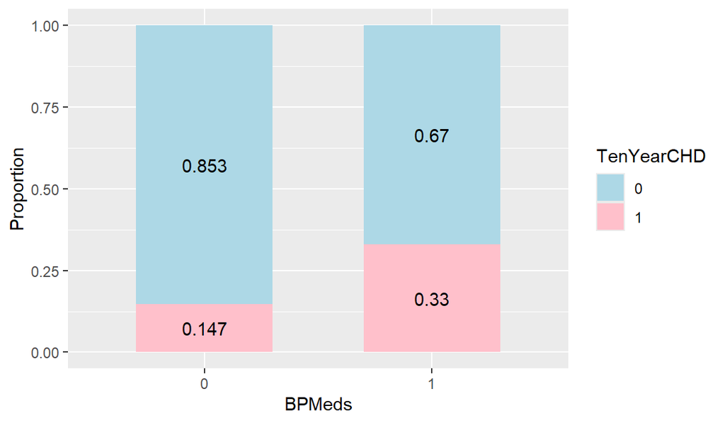

```r
#Barplot with the proportions
ggplot(train, aes(x = BPMeds, fill = TenYearCHD)) +
  geom_bar(position = "fill", width = 0.6) +
  geom_text(
  aes(label=signif(..count.. / tapply(..count.., ..x.., sum)[as.character(..x..)], digits=3)),
  stat="count",
  position=position_fill(vjust=0.5)) +
  labs(x = "BPMeds", y = "Proportion") +
  scale_fill_manual(values = c("0" = 'lightblue', "1"='pink'), name = "TenYearCHD")
```

```r
#Contingency table and chi squared test
table1 <-  table(train$BPMeds, train$TenYearCHD)
rownames(table1) <- c("BPMeds - 0", "BPMeds - 1")
colnames(table1) <- c("TenYearCHD - 0", "TenYearCHD - 1")
print(table1)
```

```
##
##              TenYearCHD - 0 TenYearCHD - 1
##   BPMeds - 0           2809            483
##   BPMeds - 1             67             33
```

```r
print(chisq.test(table1, correct = F))
```

```
##
##  Pearson's Chi-squared test
##
## data:  table1
## X-squared = 25.276, df = 1, p-value = 4.968e-07
```

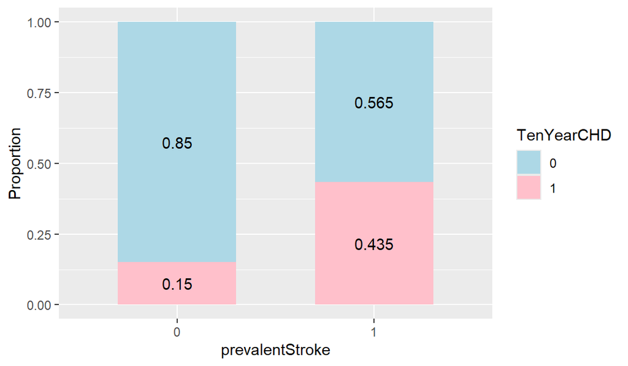

```r
ggplot(train, aes(x = prevalentStroke, fill = TenYearCHD)) +
  geom_bar(position = "fill", width = 0.6) +
  geom_text(
  aes(label=signif(..count.. / tapply(..count.., ..x.., sum)[as.character(..x..)], digits=3)),
  stat="count",
  position=position_fill(vjust=0.5)) +
  labs(x = "prevalentStroke", y = "Proportion") +
  scale_fill_manual(values = c("0" = "lightblue", "1" = "pink"), name = "TenYearCHD")
```

```r
#Contingency table and chi squared test
table2 <- table(train$prevalentStroke, train$TenYearCHD)
rownames(table2) <- c("prevalentStroke - 0", "prevalentStroke - 1")
colnames(table2) <- c("TenYearCHD - 0", "TenYearCHD - 1")
print(table2)
```

```
##
##                       TenYearCHD - 0 TenYearCHD - 1
##   prevalentStroke - 0           2863            506
##   prevalentStroke - 1             13             10
```

```r
print(chisq.test(table2, correct = F))
```

```
##
##  Pearson's Chi-squared test
##
## data:  table2
## X-squared = 14.344, df = 1, p-value = 0.0001522
```

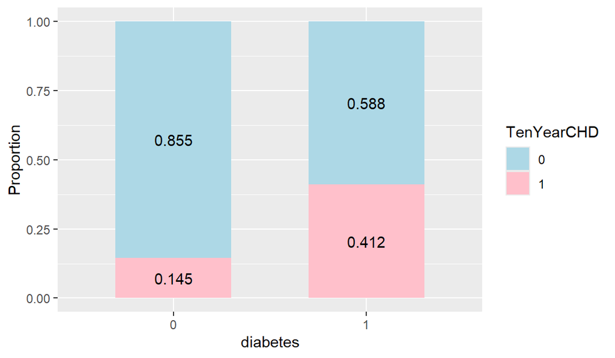

```r
ggplot(train, aes(x = diabetes, fill = TenYearCHD)) +
  geom_bar(position = "fill", width = 0.6) +
   geom_text(
  aes(label=signif(..count.. / tapply(..count.., ..x.., sum)[as.character(..x..)], digits=3)),
  stat="count",
  position=position_fill(vjust=0.5)) +
  labs(x = "diabetes", y = "Proportion") +
  scale_fill_manual(values = c("0" = "lightblue", "1" = "pink"), name = "TenYearCHD")
```

```r
#Contingency table and chi squared test
table3 <- table(train$diabetes, train$TenYearCHD)
rownames(table3) <- c("diabetes - 0", "diabetes - 1")
colnames(table3) <- c("TenYearCHD - 0", "TenYearCHD - 1")
print(table3)
```

```
##
##                TenYearCHD - 0 TenYearCHD - 1
##   diabetes - 0           2826            481
##   diabetes - 1             50             35
```

```r
print(chisq.test(table3, correct = F))
```

```
##
##  Pearson's Chi-squared test
##
## data:  table3
## X-squared = 45.568, df = 1, p-value = 1.474e-11
```

Looking at the above barplots, it can be seen that the proportion of people with risk of having CHD changes significantly for the categories of “BPMeds”, “prevalentStroke” and “diabetes”. Besides, the $\chi^2$ test, shows that there is enough evidence to reject the null hypothesis **$H_0:$ There is no association between this variables and the target** To end with the analysis of the relation between the categorical predictors and the target, we explore visually if the feature “education” is associated with the target, because at first glance it might seem that the level “education” has nothing to do with the risk of having a CHD in the future.

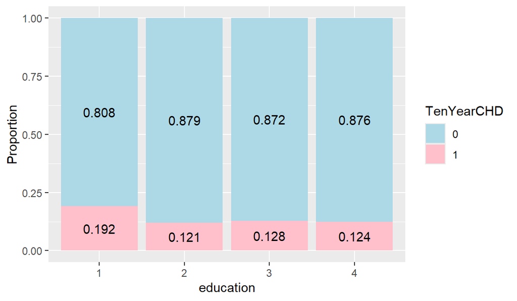

```r
ggplot(train, aes(x = education, fill = TenYearCHD)) +
  geom_bar(position = "fill") +
   geom_text(
  aes(label=signif(..count.. / tapply(..count.., ..x.., sum)[as.character(..x..)], digits=3)),
  stat="count",
  position=position_fill(vjust=0.5)) +
  labs(x = "education", y = "Proportion") +
  scale_fill_manual(values = c("0" = "lightblue", "1" = "pink"), name = "TenYearCHD")
```

The proportion of people with risk of CHD for the levels of education $2,3,4$ are approximately the same and there is only a slight difference for the level of education $1$. So, it is chosen to delete this variable from the dataset. In this case, the $\chi^2$ test is not appropriate since “education” is a categorical ordinal variable.

```r
train <- train %>% select(-education)
test_imputed <- test_imputed %>% select(-education)
```

Next, a pair plot is created using the numerical variables in the dataset, while also distinguishing between different values of the target variable. This is done to assess the presence of multicollinearity and to identify which numerical variables exhibit strong dependencies on the target variable.

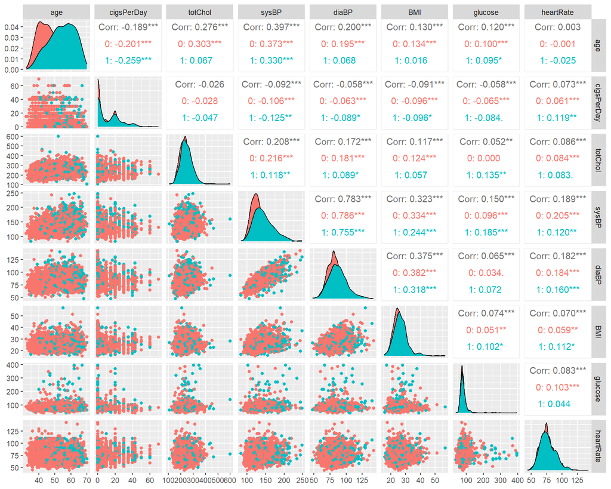

```r
numeric_columns <- c('age','cigsPerDay','totChol','sysBP','diaBP','BMI','glucose','heartRate')
  ggpairs(data = train ,columns = numeric_columns, aes(color = TenYearCHD))
```

In this plot, we observe that the variables are not highly correlated with each other, indicating low multicollinearity. The only pair of variables that appears to be highly correlated are “Sys BP” and “Dia BP,” which is expected since both variables measure blood pressure in different ways. Additionally, the predictors with the highest dependence on the target variable are “age,” “Sys BP,” and “Dia BP.” However, one might anticipate that the variable “cigarettes per day” has a significant impact on the risk of coronary heart disease. We can explore this relationship in more detail using a boxplot:

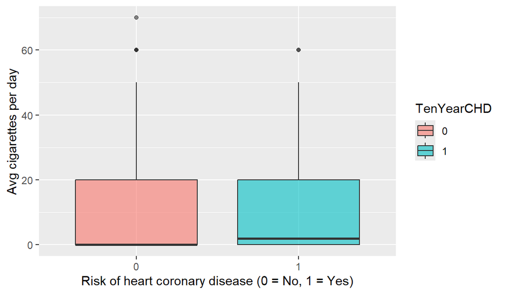

```r
ggplot(train, aes(x = TenYearCHD , y = cigsPerDay, fill = TenYearCHD)) +
  geom_boxplot(alpha = 0.6) +
  labs(x = "Risk of heart coronary disease (0 = No, 1 = Yes)", y = "Avg cigarettes per day")
```

The collected data suggests that there is not a significant relationship between the average number of cigarettes smoked and the risk of CHD. However, it is notable that the median number of cigarettes is slightly higher for patients with a risk of CHD.

Correlation heatmap between numerical variables:

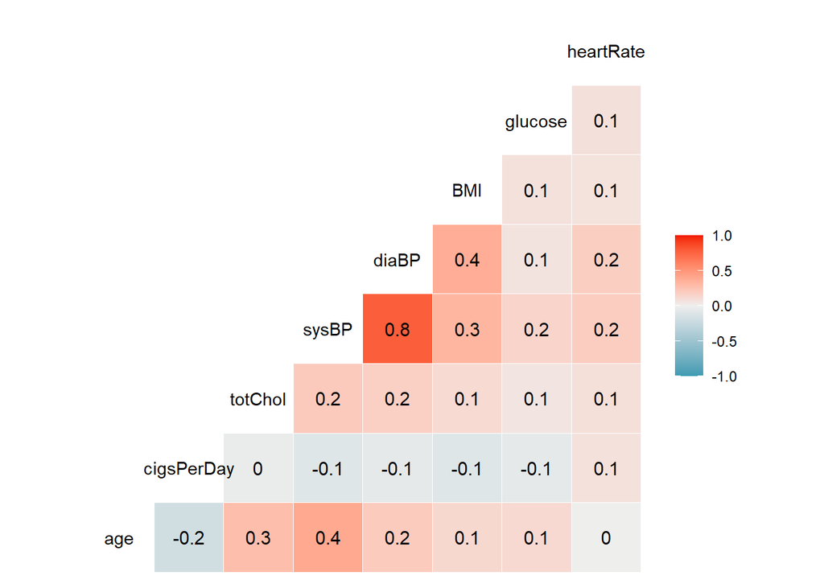

```r
ggcorr(train[,numeric_columns], label = TRUE)
```

As observed in the pair plot, the only pair of variables exhibiting a high correlation is “Sys BP” and “Dia BP”. We examine the relationship of these two variables with the target and exclude the one that shows less dependence on the target.

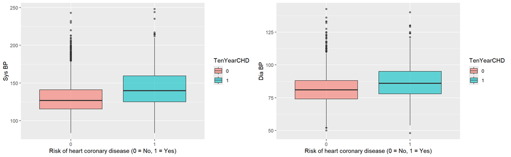

```r
 boxplot1 <- ggplot(train, aes(x = TenYearCHD , y = sysBP, fill = TenYearCHD)) +
       geom_boxplot(alpha = 0.6) +
       labs(x = "Risk of heart coronary disease (0 = No, 1 = Yes)", y = "Sys BP")

boxplot2 <- ggplot(train, aes(x = TenYearCHD , y = diaBP, fill = TenYearCHD)) +
       geom_boxplot(alpha = 0.6) +
       labs(x = "Risk of heart coronary disease (0 = No, 1 = Yes)", y = "Dia BP")

grid.arrange(boxplot1, boxplot2, ncol = 2)
```

Looking at the boxplots, it seems that the systolic pressure have more effect on the risk of CHD than the diastolic pressure, so we delete “diaBP” from the dataset

```r
train <- train %>% select(-diaBP)
test_imputed <- test_imputed %>% select(-diaBP)
```

Since in the pairplot appears that all the numeric variables are right skewed, we transform them so that they are approximately symmetric and closer to a normal distribution. The reason behind is that for some statistical learning methods such as QDA, LDA and Naive Bayes, one of the assumptions is that the data is normally distributed.

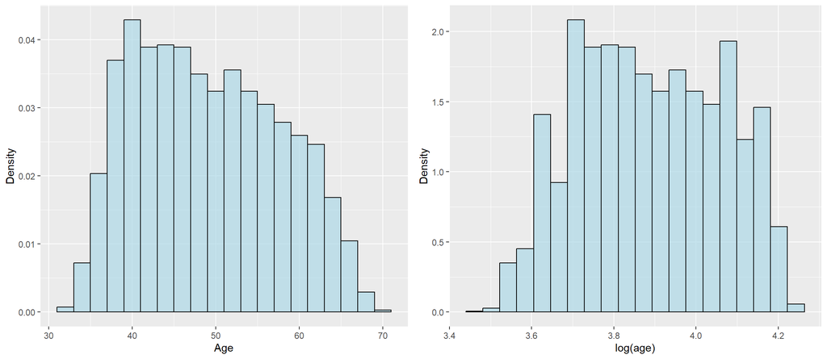

```r
plot1 <- ggplot(train, aes(x = age)) +
  geom_histogram(aes(y = ..density..), bins = 20, fill = "lightblue", color = "black", alpha = 0.7) +
  labs(x = "Age", y = "Density")


plot2 <- ggplot(train, aes(x = log(age))) +
  geom_histogram(aes(y = ..density..), bins = 20, fill = "lightblue", color = "black", alpha = 0.7) +
  labs(x = "log(age)", y = "Density")

grid.arrange(plot1, plot2, ncol = 2)
```

The variable “age” is already symmetric although it is clearly not normally distributed, and there is no monotonic transformation that makes its distribution approach normality.

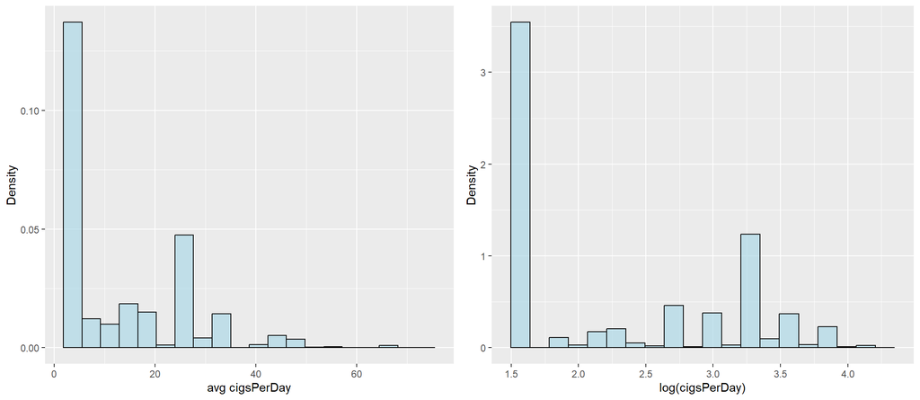

```r
#As there are many observations with  the average number of cigarettes equal to 0, we add 5, so that there are not infinite values when taking the log

plot1 <- ggplot(train, aes(x = cigsPerDay + 5)) +
  geom_histogram(aes(y = ..density..), bins = 20, fill = "lightblue", color = "black", alpha = 0.7) +
  labs(x = "avg cigsPerDay", y = "Density")


plot2 <- ggplot(train, aes(x = log(cigsPerDay + 5))) +
  geom_histogram(aes(y = ..density..), bins = 20, fill = "lightblue", color = "black", alpha = 0.7) +
  labs(x = "log(cigsPerDay)", y = "Density")

grid.arrange(plot1, plot2, ncol = 2)
```

The average number of smoked cigarettes per day (CigsPerDay) is clearly not symmetric and not normally distributed. Additionally, it is zero-inflated, with approximately half of the values being zero (representing the number of individuals who do not smoke), so there is no applicable transformation.

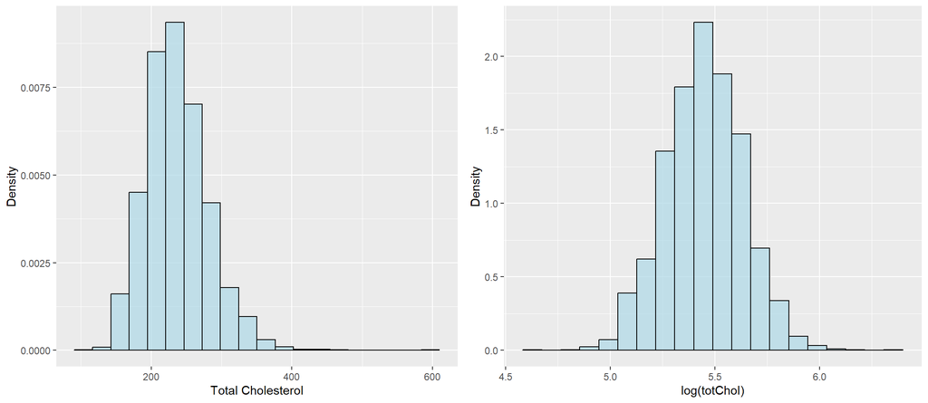

```r
plot1 <- ggplot(train, aes(x = totChol)) +
  geom_histogram(aes(y = ..density..), bins = 20, fill = "lightblue", color = "black", alpha = 0.7) +
  labs(x = "Total Cholesterol", y = "Density")


plot2 <- ggplot(train, aes(x = log(totChol))) +
  geom_histogram(aes(y = ..density..), bins = 20, fill = "lightblue", color = "black", alpha = 0.7) +
  labs(x = "log(totChol)", y = "Density")

grid.arrange(plot1, plot2, ncol = 2)
```

“TotChol” exhibits right skewness, but applying a logarithmic transformation renders its distribution symmetric and brings it closer to a normal distribution

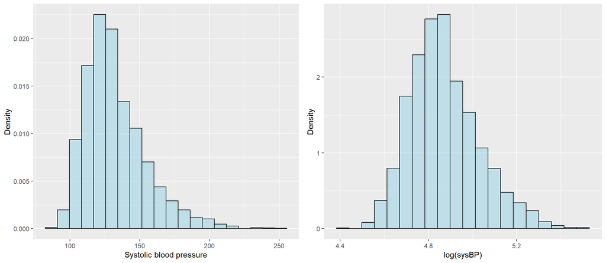

```r
plot1 <- ggplot(train, aes(x = sysBP)) +
  geom_histogram(aes(y = ..density..), bins = 20, fill = "lightblue", color = "black", alpha = 0.7) +
  labs(x = "Systolic blood pressure", y = "Density")


plot2 <- ggplot(train, aes(x = log(sysBP))) +
  geom_histogram(aes(y = ..density..), bins = 20, fill = "lightblue", color = "black", alpha = 0.7) +
  labs(x = "log(sysBP)", y = "Density")

grid.arrange(plot1, plot2, ncol = 2)
```

The attribute “SysBP” exhibits right skewness, but applying a logarithmic transformation renders its distribution symmetric and brings it closer to a normal distribution

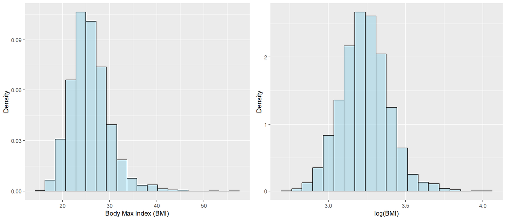

```r
plot1 <- ggplot(train, aes(x = BMI)) +
  geom_histogram(aes(y = ..density..), bins = 20, fill = "lightblue", color = "black", alpha = 0.7) +
  labs(x = "Body Max Index (BMI)", y = "Density")


plot2 <- ggplot(train, aes(x = log(BMI))) +
  geom_histogram(aes(y = ..density..), bins = 20, fill = "lightblue", color = "black", alpha = 0.7) +
  labs(x = "log(BMI)", y = "Density")

grid.arrange(plot1, plot2, ncol = 2)
```

The attribute “BMI” exhibits right skewness, but applying a logarithmic transformation renders its distribution symmetric and brings it closer to a normal distribution

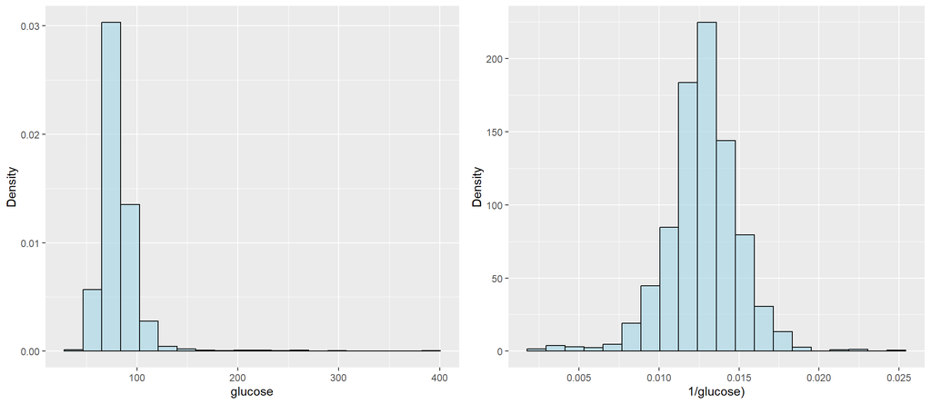

```r
plot1 <- ggplot(train, aes(x = glucose)) +
  geom_histogram(aes(y = ..density..), bins = 20, fill = "lightblue", color = "black", alpha = 0.7) +
  labs(x = "glucose", y = "Density")


plot2 <- ggplot(train, aes(x = 1/glucose)) +
  geom_histogram(aes(y = ..density..), bins = 20, fill = "lightblue", color = "black", alpha = 0.7) +
  labs(x = "1/glucose)", y = "Density")

grid.arrange(plot1, plot2, ncol = 2)
```

The attribute “glucose” displays significant right skewness with a long right tail. In this scenario, a logarithmic transformation proves ineffective, but employing an inverse transformation renders it symmetric and brings it closer to normality.

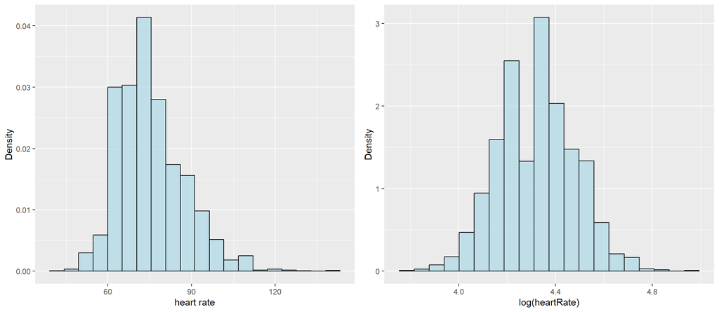

```r
plot1 <- ggplot(train, aes(x = heartRate)) +
  geom_histogram(aes(y = ..density..), bins = 20, fill = "lightblue", color = "black", alpha = 0.7) +
  labs(x = "heart rate", y = "Density")


plot2 <- ggplot(train, aes(x = log(heartRate))) +
  geom_histogram(aes(y = ..density..), bins = 20, fill = "lightblue", color = "black", alpha = 0.7) +
  labs(x = "log(heartRate)", y = "Density")

grid.arrange(plot1, plot2, ncol = 2)
```

“HeartRate” exhibits right skewness, but applying a logarithmic transformation renders its distribution symmetric and brings it closer to a normal distribution.

After analyzing the shape of the numeric variables and choosing a suitable transformation so that they are symmetric and become closer to normality, we apply these transformations in train and test sets.

```r
train$totChol <- log(train$totChol)
test_imputed$totChol <- log(test_imputed$totChol)

train$BMI <- log(train$BMI)
test_imputed$BMI <- log(test_imputed$BMI)

train$sysBP <- log(train$sysBP)
test_imputed$sysBP <- log(test_imputed$sysBP)

train$heartRate <- log(train$heartRate)
test_imputed$heartRate <- log(test_imputed$heartRate)

train$glucose <- 1/train$glucose
test_imputed$glucose <- 1/test_imputed$glucose
```

## Statistical Models

Before applying any statistical model, it is important to note that the classes of the target variable are unbalanced which can lead to a model biased towards the majority class.

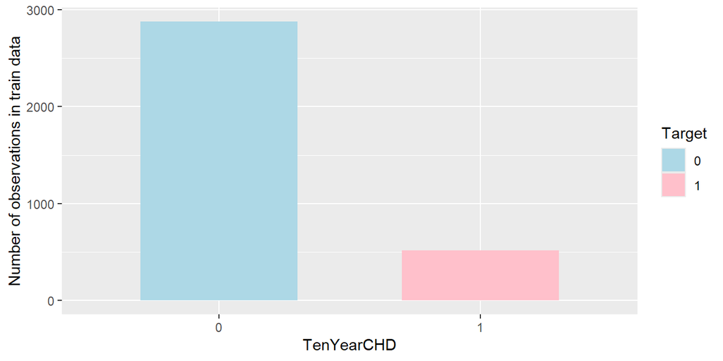

```r
count_1 <- sum(train$TenYearCHD == 1)
count_0 <- sum(train$TenYearCHD == 0)
#dataframe with the counts
counts_train <- data.frame(Target = c("1", "0"), Count = c(count_1, count_0))
#create the barplot
ggplot(counts_train, aes(x = Target, y = Count, fill = Target)) +
  geom_bar(stat = "identity", width = 0.6) +
  labs(x = "TenYearCHD", y = "Number of observations in train data") +
   scale_fill_manual(values = c("1" = "pink", "0" = "lightblue"))
```

The proportion of classes is approximately $6:1$ for the positives (individuals with risk of CHD). In order to have a more balanced training dataset and predicting more accurately the positive cases, we use Synthetic Minority Over-Sampling Technique. Summarizing, SMOTE generates new data by interpolating between randomly selected minority-class instances and their randomly chosen nearest neighbors from the minority class. One of the main drawbacks of using SMOTE is that it does not take into account majority class instances and it generates noisy instances. In order to mitigate this effect, we only create enough synthetic instances until a $2:1$ relation between negatives and positives is reached. :

Proportion of observations corresponding to each class after SMOTE imputation

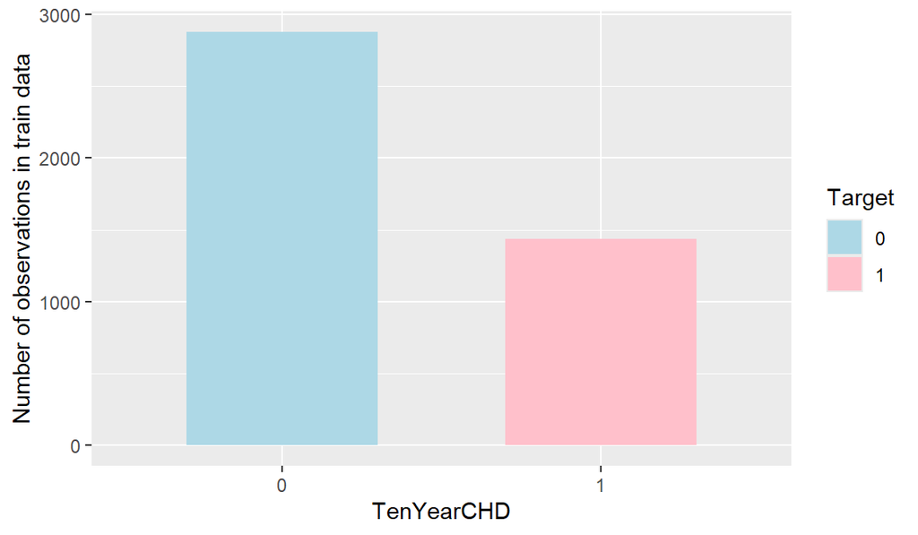

```r
count_1 <- sum(train$TenYearCHD == 1)
count_0 <- sum(train$TenYearCHD == 0)
#dataframe with the counts
counts_train <- data.frame(Target = c("1", "0"), Count = c(count_1, count_0))
#create the barplot
ggplot(counts_train, aes(x = Target, y = Count, fill = Target)) +
  geom_bar(stat = "identity", width = 0.6) +
  labs(x = "TenYearCHD", y = "Number of observations in train data") +
   scale_fill_manual(values = c("1" = "pink", "0" = "lightblue"))
```

### Logistic regression

In logistic regression, the logit transformation $\eta$ of the probability of belonging to the positive class $p$ is modelled by a line:
$$\begin{equation}
log(\frac{p}{1-p}) = \beta_0 + \beta^{T}x
\end{equation}$$
where the coefficients $\beta_j$ are obtained via MLE. The lower the value of $\eta$, the lesser is the probability of belonging to the positive class.

First of all, we train a logistic regression model including all predictors:

```r
logit_model <- glm(TenYearCHD ~., family = binomial(link = 'logit'), data = train)
#summary of the fitted model
summary(logit_model)
```

```
##
## Call:
## glm(formula = TenYearCHD ~ ., family = binomial(link = "logit"),
##     data = train)
##
## Coefficients:
##                  Estimate Std. Error z value Pr(>|z|)
## (Intercept)      -1.26180    0.08635 -14.613  < 2e-16 ***
## male1             0.64219    0.07951   8.076 6.67e-16 ***
## age               0.62032    0.04210  14.733  < 2e-16 ***
## currentSmoker1   -0.10065    0.11827  -0.851  0.39475
## cigsPerDay        0.27086    0.05763   4.700 2.60e-06 ***
## BPMeds1          -0.70245    0.23276  -3.018  0.00254 **
## prevalentStroke1  0.09323    0.47116   0.198  0.84314
## prevalentHyp1     0.08791    0.10489   0.838  0.40193
## diabetes1         0.55426    0.22399   2.474  0.01334 *
## totChol           0.04473    0.03857   1.160  0.24612
## sysBP             0.42848    0.05382   7.961 1.70e-15 ***
## BMI               0.02203    0.03896   0.565  0.57178
## heartRate         0.01640    0.03780   0.434  0.66433
## glucose          -0.06001    0.03884  -1.545  0.12230
## ---
## Signif. codes:  0 '***' 0.001 '**' 0.01 '*' 0.05 '.' 0.1 ' ' 1
##
## (Dispersion parameter for binomial family taken to be 1)
##
##     Null deviance: 5491.8  on 4313  degrees of freedom
## Residual deviance: 4697.1  on 4300  degrees of freedom
## AIC: 4725.1
##
## Number of Fisher Scoring iterations: 4
```

From the coefficients $\beta_j$ of the model it is not obvious to detect the predictors which contribute the most to the risk of CHD since we applied different transformations on them. Nevertheless, it is plain to see that in the fitted model, the coefficients corresponding to “currentSmoker”, “BPMeds” are negative which means that if the individual smokes and is taking meds for blood pressure, its probability of having risk of CHD is smaller while in reality it is the opposite.

Then we use `vif` from `car` library to check if there are redundant variables in order to avoid multicollinearity.

```r
#vif values
car::vif(logit_model)
```

```
##            male             age   currentSmoker      cigsPerDay          BPMeds
##        1.248604        1.234082        2.762070        2.888400        1.074791
## prevalentStroke    prevalentHyp        diabetes         totChol           sysBP
##        1.022698        2.116759        1.309338        1.076258        2.282317
##             BMI       heartRate         glucose
##        1.150657        1.092779        1.330458
```

All the VIF values are below $5$, indicating that the multicollinearity is not significant among the predictor variables in the model. Now, we test the goodness of fit of the model using “Hosmer-Lemeshow” test.

```r
train$TenYearCHD <- as.numeric(train$TenYearCHD) - 1
hoslem.test(train$TenYearCHD, predict(logit_model,type="response"))
```

```
##
##  Hosmer and Lemeshow goodness of fit (GOF) test
##
## data:  train$TenYearCHD, predict(logit_model, type = "response")
## X-squared = 7.3523, df = 8, p-value = 0.4991
```

```r
#We transform the target into a factor again
train$TenYearCHD <- factor(train$TenYearCHD)
```

As the p-value obtained in the “Hosmer-Lemshow” test is greater than $\alpha=0.05$, there is not enough evidence against the null hypothesis **$H_0:$ The fit is good**

Before using this logistic regression model to predict the values of the test data, we check if there are some significant interactions between features. Some interactions that come to mind are “age”-“male” and “diabetes”-“glucose”

```r
#Check the significance of male-gender interaction
interaction_model <- glm(TenYearCHD ~. + age:male, family = binomial(link = 'logit'), data = train)
anova(logit_model,interaction_model, test = "Chisq")
```

```
## Analysis of Deviance Table
##
## Model 1: TenYearCHD ~ male + age + currentSmoker + cigsPerDay + BPMeds +
##     prevalentStroke + prevalentHyp + diabetes + totChol + sysBP +
##     BMI + heartRate + glucose
## Model 2: TenYearCHD ~ male + age + currentSmoker + cigsPerDay + BPMeds +
##     prevalentStroke + prevalentHyp + diabetes + totChol + sysBP +
##     BMI + heartRate + glucose + age:male
##   Resid. Df Resid. Dev Df Deviance Pr(>Chi)
## 1      4300     4697.1
## 2      4299     4696.0  1    1.166   0.2802
```

```r
#Check the significance of diabetes - glucose
interaction_model <- glm(TenYearCHD ~. + glucose:diabetes, family = binomial(link = 'logit'), data = train)
anova(logit_model,interaction_model, test = "Chisq")
```

```
## Analysis of Deviance Table
##
## Model 1: TenYearCHD ~ male + age + currentSmoker + cigsPerDay + BPMeds +
##     prevalentStroke + prevalentHyp + diabetes + totChol + sysBP +
##     BMI + heartRate + glucose
## Model 2: TenYearCHD ~ male + age + currentSmoker + cigsPerDay + BPMeds +
##     prevalentStroke + prevalentHyp + diabetes + totChol + sysBP +
##     BMI + heartRate + glucose + glucose:diabetes
##   Resid. Df Resid. Dev Df Deviance  Pr(>Chi)
## 1      4300     4697.1
## 2      4299     4669.9  1   27.216 1.819e-07 ***
## ---
## Signif. codes:  0 '***' 0.001 '**' 0.01 '*' 0.05 '.' 0.1 ' ' 1
```

There is not enough evidence that the interaction “male”-“gender” is significant. On the contrary, the interaction “diabetes”-“glucose” is significant so we include it in the model. The last thing before training the logistic regression model is to check for the significance of each predictor using the Likelihood Ratio Test

```r
logit_model <- glm(TenYearCHD ~. + diabetes:glucose, family = binomial(link = 'logit'), data = train)
anova(logit_model, test = 'Chisq')
```

```
## Analysis of Deviance Table
##
## Model: binomial, link: logit
##
## Response: TenYearCHD
##
## Terms added sequentially (first to last)
##
##
##                  Df Deviance Resid. Df Resid. Dev  Pr(>Chi)
## NULL                              4313     5491.8
## male              1    95.48      4312     5396.4 < 2.2e-16 ***
## age               1   471.69      4311     4924.7 < 2.2e-16 ***
## currentSmoker     1     9.44      4310     4915.2  0.002128 **
## cigsPerDay        1    28.77      4309     4886.5 8.165e-08 ***
## BPMeds            1     0.25      4308     4886.2  0.616828
## prevalentStroke   1     0.09      4307     4886.1  0.770194
## prevalentHyp      1    93.27      4306     4792.9 < 2.2e-16 ***
## diabetes          1    18.38      4305     4774.5 1.812e-05 ***
## totChol           1     3.17      4304     4771.3  0.074804 .
## sysBP             1    71.14      4303     4700.2 < 2.2e-16 ***
## BMI               1     0.37      4302     4699.8  0.545099
## heartRate         1     0.29      4301     4699.5  0.590585
## glucose           1     2.39      4300     4697.1  0.121859
## diabetes:glucose  1    27.22      4299     4669.9 1.819e-07 ***
## ---
## Signif. codes:  0 '***' 0.001 '**' 0.01 '*' 0.05 '.' 0.1 ' ' 1
```

According to the LRT test, the variables that are significant are “male”, “age”, “currentSmoker”, “cigsPerDay”, “prevalentHyp”, “diabetes”, “sysBP” and the interaction “diabetes”-“glucose”. In a more detailed analysis would be a good idea to check if the performance of the model improves eliminating non significant features.

Finally, we make predictions on test data:

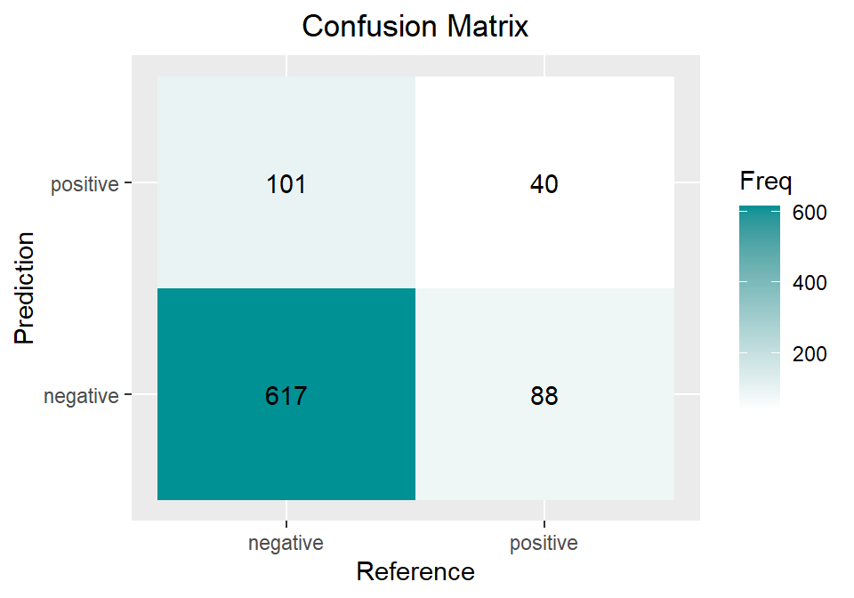

```r
predicted_probabilities <- predict(logit_model, newdata = test_imputed, type = 'response')
#use p = 0.5 as a naive threshold
predicted_classes <- ifelse(predicted_probabilities > 0.5,1,0)
predicted_classes <- factor(predicted_classes)
#Confusion matrix with the results
conf_matrix <- confusionMatrix(data = predicted_classes, reference = test_imputed$TenYearCHD, positive = "1")
#plot the confusion matrix and several quantities
conf_matrix_table <- as.data.frame(conf_matrix$table)


ggplot(conf_matrix_table, aes(x = Reference, y = Prediction,fill= Freq)) +
        geom_tile() + geom_text(aes(label=Freq)) +
        scale_fill_gradient(low="white", high="#009194") +
        labs(x = "Reference",y = "Prediction") +
        scale_x_discrete(labels=c("negative","positive")) +
        scale_y_discrete(labels=c("negative", "positive")) +
        ggtitle("Confusion Matrix") +
        theme(plot.title = element_text(hjust = 0.5))
```

```r
#dataframe with some metrics
metrics_df <- data.frame(
  Value = c(conf_matrix$byClass["Sensitivity"],
            conf_matrix$byClass["Specificity"],
            conf_matrix$overall["Kappa"],
            conf_matrix$overall["Accuracy"])
)

#show the dataframe
print(metrics_df)
```

```
##                 Value
## Sensitivity 0.3125000
## Specificity 0.8593315
## Kappa       0.1649485
## Accuracy    0.7765957
```

### Quadrant discriminant analysis (QDA)

Now, we apply bayes classifiers. The first one is QDA which is suitable for datasets with many observations, small dimensionality and assumes that the predictors are normally distributed. In this particular dataset, after applying some transformations, most of the numerical predictors seem to follow a normal distribution excpect “cigsPerDay” and “age” which can affect negatively the performance of QDA.

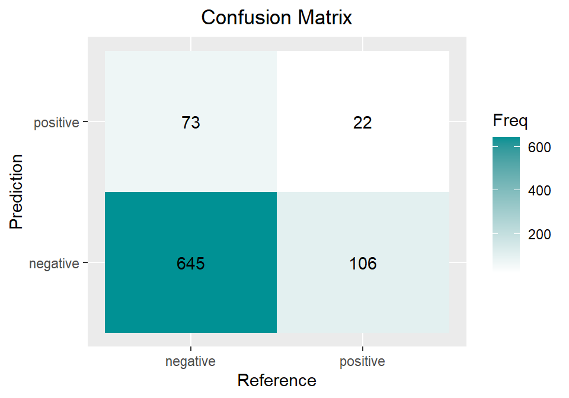

```r
library(MASS)
#We fit the qda model
qda_model <- qda(TenYearCHD ~., data = train)
#make the predictions
qda_probabilities <- predict(qda_model, newdata = test_imputed)$posterior[,2]
qda_classes <- ifelse(qda_probabilities > 0.5,1,0)
qda_classes <- factor(qda_classes)
#Confusion matrix with the results
conf_matrix <- confusionMatrix(data = qda_classes, reference = test_imputed$TenYearCHD, positive = "1")

#plot the confusion matrix and several quantities
conf_matrix_table <- as.data.frame(conf_matrix$table)
ggplot(conf_matrix_table, aes(x = Reference, y = Prediction,fill= Freq)) +
        geom_tile() + geom_text(aes(label=Freq)) +
        scale_fill_gradient(low="white", high="#009194") +
        labs(x = "Reference",y = "Prediction") +
        scale_x_discrete(labels=c("negative","positive")) +
        scale_y_discrete(labels=c("negative", "positive")) +
        ggtitle("Confusion Matrix") +
        theme(plot.title = element_text(hjust = 0.5))
```

```r
#dataframe with some metrics
metrics_df <- data.frame(
  Value = c(conf_matrix$byClass["Sensitivity"],
            conf_matrix$byClass["Specificity"],
            conf_matrix$overall["Kappa"],
            conf_matrix$overall["Accuracy"])
)

#show the dataframe
print(metrics_df)
```

```
##                 Value
## Sensitivity 0.1718750
## Specificity 0.8983287
## Kappa       0.0785211
## Accuracy    0.7884161
```

### LDA model

The second bayes classifier is LDA, which is suitable for multivariate gaussian predictors and it assumes that all the predictors have the same covariance matrix and that the classes are linearly separable.

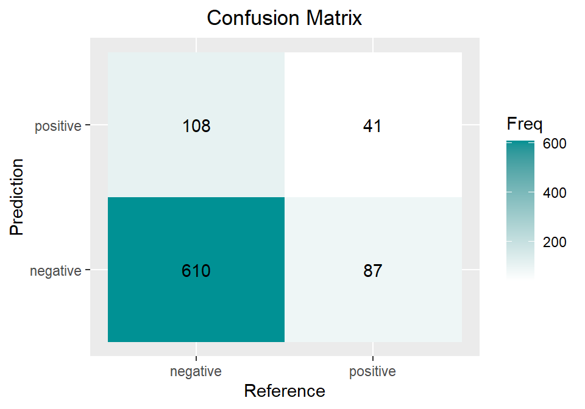

```r
#We fit the LDA model
lda_model <- lda(TenYearCHD ~., data = train)
#make the predictions
lda_probabilities <- predict(lda_model, newdata = test_imputed)$posterior[,2]
lda_classes <- ifelse(lda_probabilities > 0.5,1,0)
lda_classes <- factor(lda_classes)
#Confusion matrix with the results
conf_matrix <- confusionMatrix(data = lda_classes, reference = test_imputed$TenYearCHD, positive = "1")

#plot the confusion matrix and several quantities
conf_matrix_table <- as.data.frame(conf_matrix$table)


ggplot(conf_matrix_table, aes(x = Reference, y = Prediction,fill= Freq)) +
        geom_tile() + geom_text(aes(label=Freq)) +
        scale_fill_gradient(low="white", high="#009194") +
        labs(x = "Reference",y = "Prediction") +
        scale_x_discrete(labels=c("negative","positive")) +
        scale_y_discrete(labels=c("negative", "positive")) +
        ggtitle("Confusion Matrix") +
        theme(plot.title = element_text(hjust = 0.5))
```

```r
#dataframe with some metrics
metrics_df <- data.frame(
  Value = c(conf_matrix$byClass["Sensitivity"],
            conf_matrix$byClass["Specificity"],
            conf_matrix$overall["Kappa"],
            conf_matrix$overall["Accuracy"])
)

#show the dataframe
print(metrics_df)
```

```
##                 Value
## Sensitivity 0.3203125
## Specificity 0.8495822
## Kappa       0.1591657
## Accuracy    0.7695035
```

### Naive Bayes model

Finally, we apply Naive Bayes, which assumes that the predictors are independent and it works well in datasets with high dimensionality. As in this dataset, there are some categorical predictors, it is used `naive_bayes` from `naivebayes` package in R. This function apply Gaussian Naive Bayes to the numeric variables and Bernouilli Naive Bayes for categorical ones.

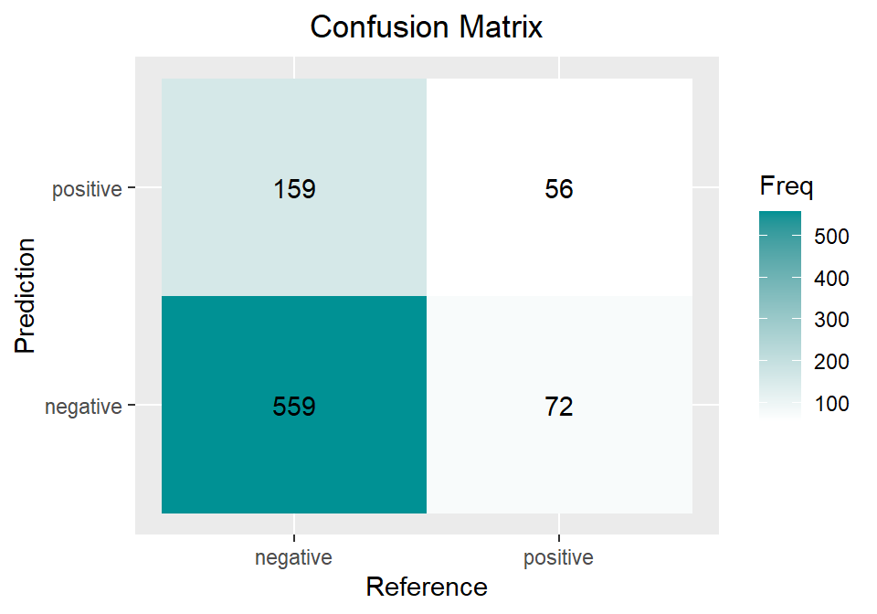

```r
#we fit naive_bayes that assumes gaussian distribution and independence for numeric variables
#and bernoilli for categorical ones
nb_model <- naive_bayes(TenYearCHD ~., data = train)
#make the predictions
nb_probabilities <- predict(nb_model, newdata = test_imputed, type = 'prob')[,2]

nb_classes <- ifelse(nb_probabilities > 0.5,1,0)
nb_classes <- factor(nb_classes)
#Confusion matrix with the results
conf_matrix <- confusionMatrix(data = nb_classes, reference = test_imputed$TenYearCHD, positive = "1")

#plot the confusion matrix and several quantities
conf_matrix_table <- as.data.frame(conf_matrix$table)


ggplot(conf_matrix_table, aes(x = Reference, y = Prediction,fill= Freq)) +
        geom_tile() + geom_text(aes(label=Freq)) +
        scale_fill_gradient(low="white", high="#009194") +
        labs(x = "Reference",y = "Prediction") +
        scale_x_discrete(labels=c("negative","positive")) +
        scale_y_discrete(labels=c("negative", "positive")) +
        ggtitle("Confusion Matrix") +
        theme(plot.title = element_text(hjust = 0.5))
```

```r
#dataframe with some metrics
metrics_df <- data.frame(
  Value = c(conf_matrix$byClass["Sensitivity"],
            conf_matrix$byClass["Specificity"],
            conf_matrix$overall["Kappa"],
            conf_matrix$overall["Accuracy"])
)

#show the dataframe
print(metrics_df)
```

```
##                 Value
## Sensitivity 0.4375000
## Specificity 0.7785515
## Kappa       0.1688881
## Accuracy    0.7269504
```

To compare, as the target variable is still imbalanced in the training set, we set the prior probabilities $\pi_0$,$\pi_1$ = 0.5 to compare the results with the previous one, which estimates these prior probabilities as the proportions present in the dataset.

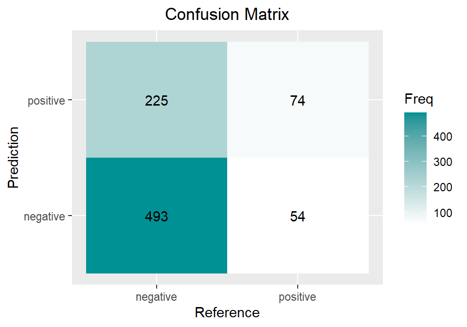

```r
nb_model2 <- naive_bayes(TenYearCHD ~., data = train, prior = c(0.5,0.5))
#make the predictions
nb_probabilities2 <- predict(nb_model2, newdata = test_imputed, type = 'prob')[,2]

nb_classes2 <- ifelse(nb_probabilities2 > 0.5,1,0)
nb_classes2 <- factor(nb_classes2)
#Confusion matrix with the results
conf_matrix <- confusionMatrix(data = nb_classes2, reference = test_imputed$TenYearCHD, positive = "1")

#plot the confusion matrix and several quantities
conf_matrix_table <- as.data.frame(conf_matrix$table)


ggplot(conf_matrix_table, aes(x = Reference, y = Prediction,fill= Freq)) +
        geom_tile() + geom_text(aes(label=Freq)) +
        scale_fill_gradient(low="white", high="#009194") +
        labs(x = "Reference",y = "Prediction") +
        scale_x_discrete(labels=c("negative","positive")) +
        scale_y_discrete(labels=c("negative", "positive")) +
        ggtitle("Confusion Matrix") +
        theme(plot.title = element_text(hjust = 0.5))
```

```r
#dataframe with some metrics
metrics_df <- data.frame(
  Value = c(conf_matrix$byClass["Sensitivity"],
            conf_matrix$byClass["Specificity"],
            conf_matrix$overall["Kappa"],
            conf_matrix$overall["Accuracy"])
)

#show the dataframe
print(metrics_df)
```

```
##                 Value
## Sensitivity 0.5781250
## Specificity 0.6866295
## Kappa       0.1709320
## Accuracy    0.6702128
```

In all the models, the accuracy is less than the one that would be obtained applying a naive classifier which sets the risk of having a CHD of all individuals as $0$ ($85$% of accuracy) . This difference in accuracy is due to the synthetic imputation of the minority class that was done before. Apart from that, all the methods have a high specificity and a low sensitivity, that is, predict well the negative cases but they do not detect well the positives ones. The model with the highest sensitivity is Naive Bayes classifier with prior probabilities equal to $0.5$, which is also the one with lowest accuracy. Another interesting metric is kappa, which measures how well the classifier performs compared to predictions made by chance. Across all models, the kappa values are below $0.2$, with the second Naive Bayes classifier achieving the highest value and QDA the lowest.

```r
 #accuracy of a naive classificator
dim(test_imputed[test_imputed$TenYearCHD == 1,])[1]/dim(test_imputed)[1]
```

```
## [1] 0.1513002
```

To determine the most suitable metric for comparing and selecting the optimal model, it is essential to consider that generally, in disease diagnosis, the economic cost is not as important as in other situations, and the priority is usually to correctly diagnose all individuals at risk of suffering from that disease (maximize the proportion of true positives) while also reducing the number of false alarms (reduce the proportion of false positives). For that reason, the best way to compare models and choose the optimal threshold is by comparing the ROC curves of the different models.

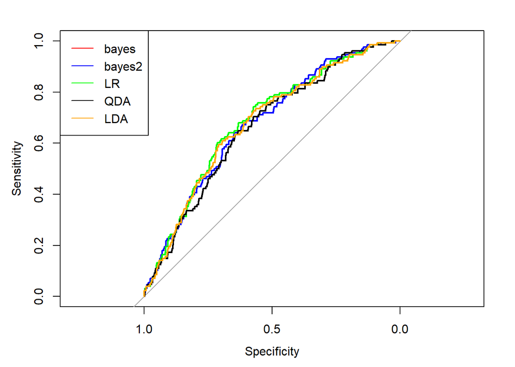

```r
library(pROC)
#let's go for logistic regression
roc_bayes <- roc(test_imputed$TenYearCHD ~ nb_probabilities)
roc_bayes2 <- roc(test_imputed$TenYearCHD ~ nb_probabilities2)
roc_lr <- roc(test_imputed$TenYearCHD ~ predicted_probabilities)
roc_qda <- roc(test_imputed$TenYearCHD ~ qda_probabilities)
roc_lda <- roc(test_imputed$TenYearCHD ~ lda_probabilities)
plot(roc_bayes ,col = 'red')
plot(roc_bayes2, add = TRUE ,col = 'blue')
plot(roc_lr, add = TRUE,col = 'green')
plot(roc_qda, add = TRUE ,col = 'black')
plot(roc_lda, add = TRUE,col = 'orange')
legend("topleft", legend=c("bayes","bayes2","LR","QDA","LDA"), col=c("red","blue","green","black","orange"), lwd=1.2)
```

Comparing the ROC curves, it appears that Linear Regression model is the best. To analyze it quantitatively, we compare the AUC values.

```r
auc_values <- data.frame( Model = c('Bayes','Bayes2','LR','QDA','LDA'),
                          AUC = c(auc(roc_bayes), auc(roc_bayes2), auc(roc_lr),
                                  auc(roc_qda), auc(roc_lda)))
auc_values
```

```
##    Model       AUC
## 1  Bayes 0.6758030
## 2 Bayes2 0.6758030
## 3     LR 0.6855958
## 4    QDA 0.6628058
## 5    LDA 0.6780662
```

All AUC values fall between $0.66$ and $0.68$, with the Logistic Regression model achieving the highest AUC, followed by LDA and Naive Bayes. Interestingly, despite using different prior probabilities, both Naive Bayes models yield the same AUC. With an AUC of $0.686$, the performance of the logistic model is deemed ‘acceptable’ for discriminating individuals at risk of a ten-year CHD. The optimal probability threshold $p$ corresponds to the closest point of the ROC curve to the top left corner of the plot which represents a model that perfectly discriminates both classes.

```r
#optimal probability threshold
p_threshold <- coords(roc_lr, "best", ret = "threshold")$threshold
print(p_threshold)
```

```
## [1] 0.3434811
```

Now, we use the value of $p$ obtained to assign the classes to the predicted probabilities of the Logistic Regression model:

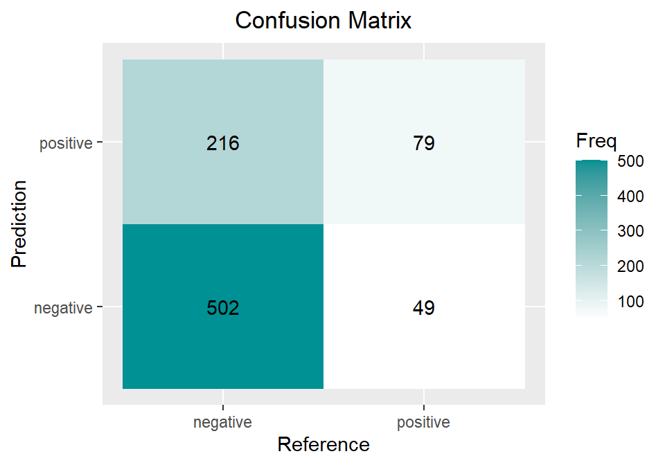

```r
predicted_classes <- ifelse(predicted_probabilities > p_threshold,1,0)
predicted_classes <- factor(predicted_classes)
#Confusion matrix with the results
conf_matrix <- confusionMatrix(data = predicted_classes, reference = test_imputed$TenYearCHD, positive = "1")
#plot the confusion matrix and several quantities
conf_matrix_table <- as.data.frame(conf_matrix$table)

ggplot(conf_matrix_table, aes(x = Reference, y = Prediction,fill= Freq)) +
        geom_tile() + geom_text(aes(label=Freq)) +
        scale_fill_gradient(low="white", high="#009194") +
        labs(x = "Reference",y = "Prediction") +
        scale_x_discrete(labels=c("negative","positive")) +
        scale_y_discrete(labels=c("negative", "positive")) +
        ggtitle("Confusion Matrix") +
        theme(plot.title = element_text(hjust = 0.5))
```

```r
#dataframe with some metrics
metrics_df <- data.frame(
  Value = c(conf_matrix$byClass["Sensitivity"],
            conf_matrix$byClass["Specificity"],
            conf_matrix$overall["Kappa"],
            conf_matrix$overall["Accuracy"])
)

#show the dataframe
print(metrics_df)
```

```
##                 Value
## Sensitivity 0.6171875
## Specificity 0.6991643
## Kappa       0.2059517
## Accuracy    0.6867612
```

In this case, the sensitivity is considerably higher than in the previous models except for the naive bayes model with priors $\pi=0.5$ which has very similar metrics. In other words, using this threshold probability, the logistic regression model is able to predict correctly $61.7$% of the positive cases which is not a very high result but is reasonable considering that Logistic Regression, LDA and Naive Bayes are linear models and the data may have complex non linear relations. Besides, the dataset is not very large and with more observations, the performance of these models could improve significantly.

### Sensitive cost analysis

In this section, unlike the previous one where the priority was to maximize the proportion of true positives and true negatives, the objective is to minimize economic losses from the perspective of the state of the USA. These losses are defined as the payment for treatment (assuming it is covered by the state) and the potential loss of contributions from citizens due to premature death from cardiovascular disease.

In order to implement this economic analysis, we will make some assumptions based on some data found in internet:

- The annual cost per patient with a CHD disease is approximately $18.000\$$.
- The monthly average expenses of an US citizen are $3.400\$$, that is $40.800\$$ a year.
- The average life expectancy of a person with a moderate CHD is $75$ years if he or she receives treatment.
- The average life expectancy of a person with CHD without treatment is $70$ years.
- The average life expectancy in USA is $79$ years.
- The treatment for CHD lasts $15$ years on average.

Bearing in mind these assumptions, we can assign the following quantities in order to choose the threshold $p$ that allows to minimize the losses of the american state:

```r
treatment_years <- 15
treatment_cost <- 18000
losses <- c(0,0,0,0)
losses[1] <- 0
losses[2] <- treatment_cost*treatment_years
losses[3] <- 9*40800
losses[4] <- 4*40800 + treatment_years*treatment_cost
```

Now, we select the optimal threshold to minimize the economic loss for the american state.

```r
#vector containing the different probability thresholds
thresholds <- seq(0.1,0.8, length = 15)
#preinitialize the losses
state_losses <- matrix(0, nrow = 50, ncol = length(thresholds))

#loop for all possible thresholds
for(j in 1:length(thresholds)){
  #We do 50 different splits of the training data for each threshold
  for(i in 1:50){
    #A 80-20% split as our dataset is not very big
    d = createDataPartition(train$TenYearCHD, p = 0.8, list = FALSE)
    #We define our train_train and train_test samples
    train_train <- train[d,]
    train_test <- train[-d,]

    #We train the Logistic Regression Model (greatest accuracy and greatest AUC)
    threshold_model <- glm(TenYearCHD ~ ., family = binomial(link = 'logit') ,data=train_train)
    #We compute the probabilities
    threshold_probabilities = predict(threshold_model,newdata = train_test, type = 'response')

    #The instances with probability p>threshold are classified as positives
    threshold_classes <- ifelse(threshold_probabilities > thresholds[j],1,0)
    threshold_classes <- factor(threshold_classes)

    #compute the table with the confusion matrix of the model
    CM = confusionMatrix(threshold_classes, train_test$TenYearCHD)$table
    #update the a_{ij} element of the government losses matrix
    state_losses[i,j] <- sum(losses*CM)/sum(CM)
  }
}
```

Now that for each probability threshold, we have computed $50$ government losses for different splits, we show a boxplot of the losses distribution for each probability threshold

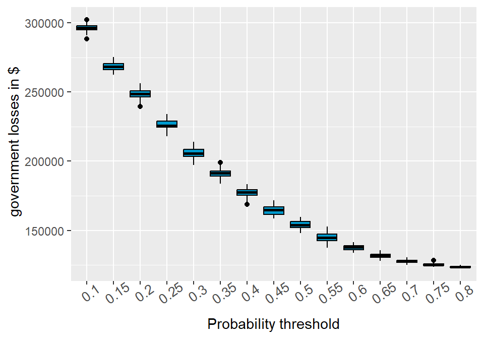

```r
ggplot(data = data.frame(reps=reshape2::melt(t(state_losses))$value,
                         cutoff = factor(rep(thresholds, 50), labels = round(thresholds, 2)))) +
  geom_boxplot(aes(x = cutoff, y = reps), fill = 'deepskyblue3', col = 'black') +
  labs(x = 'Probability threshold', y = ' government losses in $') +
  theme(axis.text.x = element_text(angle = 35, size = 10), plot.title = element_text(hjust = 0.5))
```

The economical losses follow a clear downward as the value of the probability threshold increases, if we set $p=0.8$ as threshold, the following results are obtained

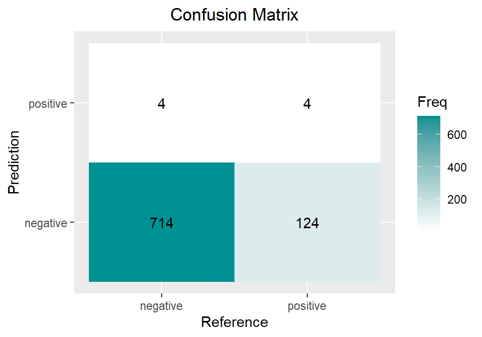

```r
predicted_classes <- ifelse(predicted_probabilities > 0.8,1,0)
predicted_classes <- factor(predicted_classes)
#Confusion matrix with the results
conf_matrix <- confusionMatrix(data = predicted_classes, reference = test_imputed$TenYearCHD, positive = "1")
#plot the confusion matrix and several quantities
conf_matrix_table <- as.data.frame(conf_matrix$table)

ggplot(conf_matrix_table, aes(x = Reference, y = Prediction,fill= Freq)) +
        geom_tile() + geom_text(aes(label=Freq)) +
        scale_fill_gradient(low="white", high="#009194") +
        labs(x = "Reference",y = "Prediction") +
        scale_x_discrete(labels=c("negative","positive")) +
        scale_y_discrete(labels=c("negative", "positive")) +
        ggtitle("Confusion Matrix") +
        theme(plot.title = element_text(hjust = 0.5))
```

```r
#dataframe with some metrics
metrics_df <- data.frame(
  Value = c(conf_matrix$byClass["Sensitivity"],
            conf_matrix$byClass["Specificity"],
            conf_matrix$overall["Kappa"],
            conf_matrix$overall["Accuracy"])
)

#show the dataframe
print(metrics_df)
```

```
##                  Value
## Sensitivity 0.03125000
## Specificity 0.99442897
## Kappa       0.04176695
## Accuracy    0.84869976
```

In this case, the specificity is almost $1$ and the sensitivity is very near $0$. These results indicate that from the state’s perspective, what would result in fewer economic losses is diagnosing the fewest positives possible since, due to their duration and cost, individuals at risk of CHD represent the greatest expense.

However, if the average duration of the CHD treatment was significantly smaller, $5$ years for instance, these results would be different:

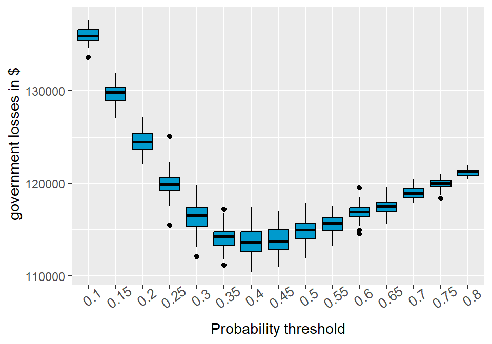

In this case, the minimum (median) loss is attained at $p = 0.4$ which mean that there has to be a balance between the number of positives and negatives and if most of the individuals are classified as positive or negative, the economic loss will be very high.

# Conclusions

To assess the individual risk of having a coronary heart disease (CHD) within the next ten years, we employed four different probabilistic learning models. While all models demonstrated acceptable accuracy overall, they exhibited limitations in predicting positive cases. Given the medical context, where the priority lies in accurately identifying true positives while minimizing false positives, we employed ROC curves and the AUC metric to compare the performance of different models. Our analysis revealed that Logistic Regression exhibited the highest AUC value. By examining the ROC curve of this model, we identified the probability threshold that optimized the balance between specificity and sensitivity. Applying this threshold to the predictions yielded by the Logistic Regression model, we attained a sensitivity of 0.6 and a specificity of 0.7. Although these values may not be considered high, they provide a valuable baseline for the potential application of more sophisticated ML algorithms. Additionally, the interpretability of these models makes them advantageous in medical settings.

To conclude the analysis, we devised a hypothetical scenario aimed at minimizing losses for a the U.S. state, based on data sourced from the internet. The outcome depends on the average treatment duration; over a 15-year period, it is most advantageous to classify the majority of individuals as not at risk of developing cardiovascular disease to minimize economic losses. If the treatment duration is shorter, the optimal value for $p$ decreases, indicating a need to find a balance between classifying individuals as positive or negative. However, it’s worth noting that this scenario lacks realism, as the value of a human life cannot be quantified with the number.